# Oasis dataset: MRI and Alzheimers

Livio Finos

# Info data

https://www.kaggle.com/datasets/jboysen/mri-and-alzheimers

**Context:**

The Open Access Series of Imaging Studies (OASIS) is a project aimed at making MRI data sets of the brain freely available to the scientific community. By compiling and freely distributing MRI data sets, we hope to facilitate future discoveries in basic and clinical neuroscience. OASIS is made available by the Washington University Alzheimer’s Disease Research Center, Dr. Randy Buckner at the Howard Hughes Medical Institute (HHMI)( at Harvard University, the Neuroinformatics Research Group (NRG) at Washington University School of Medicine, and the Biomedical Informatics Research Network (BIRN).

**Content:**

Longitudinal MRI Data in Nondemented and Demented Older Adults: This set consists of a longitudinal collection of 150 subjects aged 60 to 96. Each subject was scanned on two or more visits, separated by at least one year for a total of 373 imaging sessions. For each subject, 3 or 4 individual T1-weighted MRI scans obtained in single scan sessions are included. The subjects are all right-handed and include both men and women. 72 of the subjects were characterized as nondemented throughout the study. 64 of the included subjects were characterized as demented at the time of their initial visits and remained so for subsequent scans, including 51 individuals with mild to moderate Alzheimer’s disease. Another 14 subjects were characterized as nondemented at the time of their initial visit and were subsequently characterized as demented at a later visit.

**Acknowledgements:**

When publishing findings that benefit from OASIS data, please include the following grant numbers in the acknowledgements section and in the associated Pubmed Central submission: P50 AG05681, P01 AG03991, R01 AG021910, P20 MH071616, U24 RR0213

# Import data

```r
dati=read.csv(file = "oasis_longitudinal.csv")

dati$Group=factor(dati$Group,levels=c("Nondemented","Converted","Demented"))

# da qui 0 è pari a Age=77
dati$Age=dati$Age-77
```

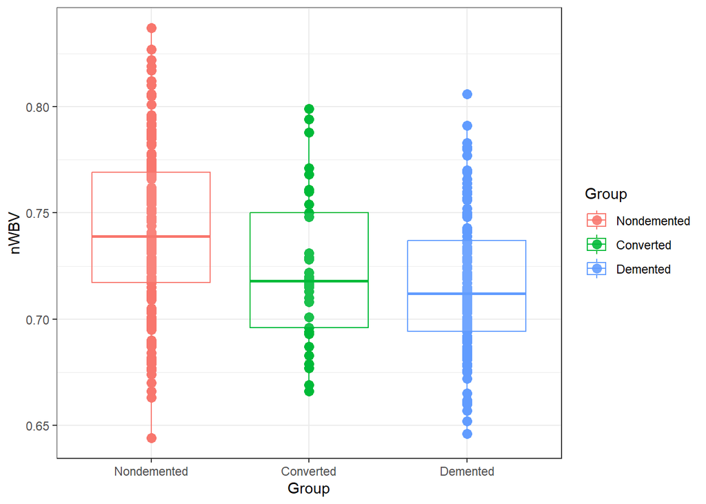

```r
library(ggplot2)
p <- ggplot(dati,aes(Group,nWBV,color=Group))
p+geom_point(size = 3) +geom_boxplot(alpha=.1) + theme_bw()
```

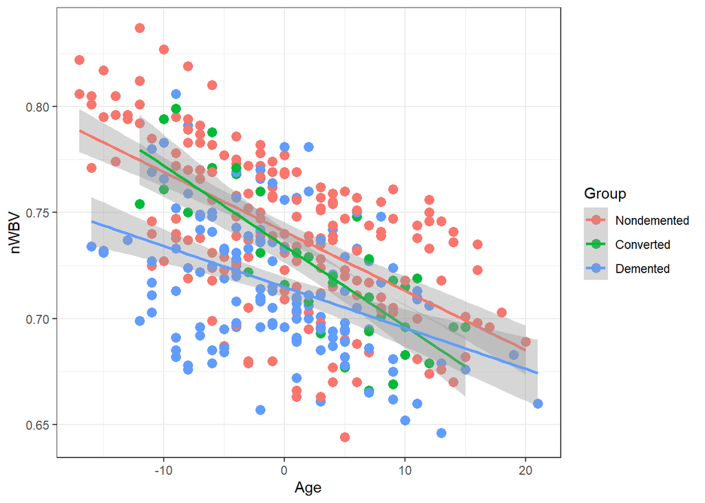

```r
p <- ggplot(dati,aes(Age,nWBV,color=Group))
p+geom_point(size = 3) +geom_smooth(method = lm) + theme_bw()
```

# Mixed Model Approach

```r
library(lmerTest)
```

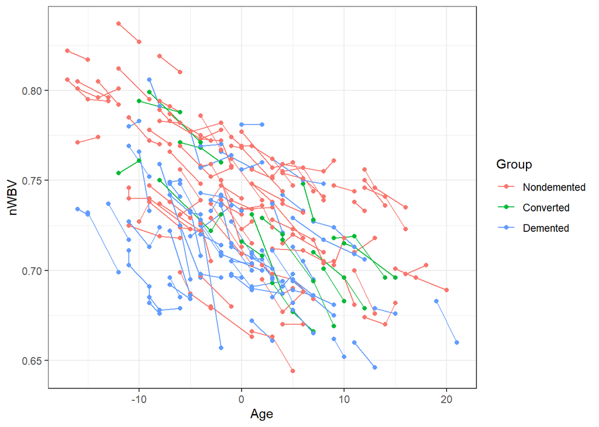

```r
library(ggplot2)

p=ggplot(dati, aes(x = Age, y = nWBV, colour = Group, group = Subject.ID)) + geom_line() + geom_point()
p + theme_bw()
```

```r
mod=lmer(nWBV ~ Age*Group+(1+Age|Subject.ID),data=dati)
summary(mod)
```

```
## Linear mixed model fit by REML. t-tests use Satterthwaite's method [
## lmerModLmerTest]
## Formula: nWBV ~ Age * Group + (1 + Age | Subject.ID)
##    Data: dati
##
## REML criterion at convergence: -1947.8
##
## Scaled residuals:
##     Min      1Q  Median      3Q     Max
## -4.0463 -0.4519  0.0242  0.4241  3.7851
##
## Random effects:
##  Groups     Name        Variance  Std.Dev.  Corr
##  Subject.ID (Intercept) 8.511e-04 0.0291728
##             Age         9.078e-07 0.0009528 0.26
##  Residual               6.175e-05 0.0078581
## Number of obs: 373, groups:  Subject.ID, 150
##
## Fixed effects:
##                      Estimate Std. Error         df t value Pr(>|t|)
## (Intercept)         7.400e-01  3.584e-03  1.245e+02 206.464  < 2e-16 ***
## Age                -3.261e-03  2.990e-04  6.140e+01 -10.906 5.33e-16 ***
## GroupConverted     -1.830e-03  8.898e-03  1.316e+02  -0.206   0.8373
## GroupDemented      -2.578e-02  5.226e-03  1.259e+02  -4.933 2.51e-06 ***
## Age:GroupConverted -1.848e-03  7.046e-04  5.663e+01  -2.623   0.0112 *
## Age:GroupDemented  -4.122e-04  5.031e-04  8.814e+01  -0.819   0.4148
## ---
## Signif. codes:  0 '***' 0.001 '**' 0.01 '*' 0.05 '.' 0.1 ' ' 1
##
## Correlation of Fixed Effects:
##             (Intr) Age    GrpCnv GrpDmn Ag:GrC
## Age          0.122
## GroupCnvrtd -0.403 -0.049
## GroupDemntd -0.686 -0.083  0.276
## Ag:GrpCnvrt -0.052 -0.424  0.016  0.035
## Ag:GrpDmntd -0.072 -0.594  0.029  0.158  0.252
```

```r
# mod=lmer(nWBV ~ Age*Group+Gender*Group+(1|Subject.ID),data=dati)
# summary(mod)
# anova(mod)


library(emmeans)
emm=emmeans(mod,~Group|Age)
emm
```

```
## Age = 0.0134:
##  Group       emmean      SE  df lower.CL upper.CL
##  Nondemented  0.740 0.00361 145    0.733    0.747
##  Converted    0.738 0.00819 147    0.722    0.754
##  Demented     0.714 0.00382 144    0.707    0.722
##
## Degrees-of-freedom method: kenward-roger
## Confidence level used: 0.95
```

```r
# modc_mcp=pairs(emm, "trt.vs.ctrl1")
modc_mcp=pairs(emm)
modc_mcp
```

```
## Age = 0.0134:
##  contrast                estimate      SE  df t.ratio p.value
##  Nondemented - Converted  0.00186 0.00895 147   0.207  0.9766
##  Nondemented - Demented   0.02579 0.00526 145   4.905  <.0001
##  Converted - Demented     0.02393 0.00904 147   2.647  0.0243
##
## Degrees-of-freedom method: kenward-roger
## P value adjustment: tukey method for comparing a family of 3 estimates
```

```r
con1 <- contrast(emm, interaction = "pairwise")
pairs(con1, by = NULL)
```

```
##  contrast
##  (Nondemented - Converted Age0.0134048257372654) - (Nondemented - Demented Age0.0134048257372654)
##  (Nondemented - Converted Age0.0134048257372654) - (Converted - Demented Age0.0134048257372654)
##  (Nondemented - Demented Age0.0134048257372654) - (Converted - Demented Age0.0134048257372654)
##  estimate      SE  df t.ratio p.value
##  -0.02393 0.00904 147  -2.647  0.0243
##  -0.02207 0.01720 147  -1.283  0.4071
##   0.00186 0.00895 147   0.207  0.9766
##
## Degrees-of-freedom method: kenward-roger
## P value adjustment: tukey method for comparing a family of 3 estimates
```

## Plotting tools

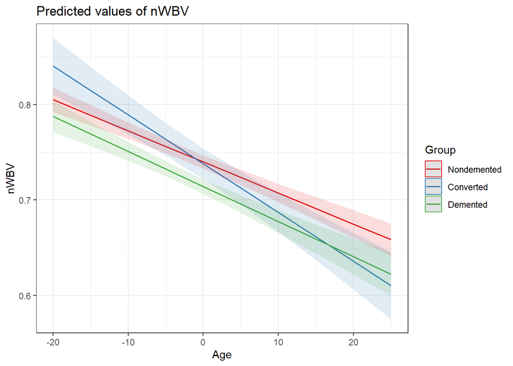

```r
library(sjPlot)
library(ggplot2)
#plot_model(mod, type = "pred", terms = c("Group", "Age"))+theme_bw()
plot_model(mod, type = "pred", terms = c("Age","Group"))+theme_bw()
```

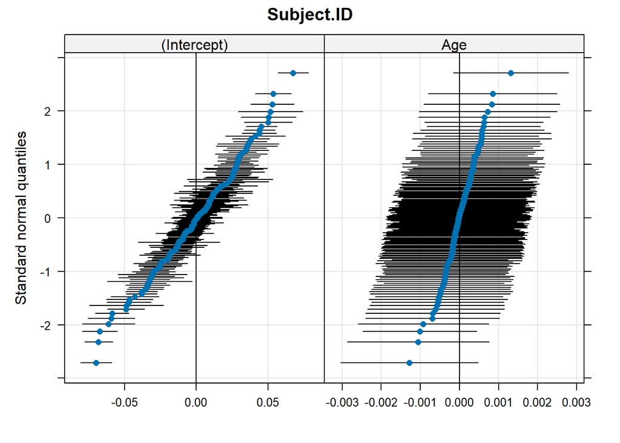

```r
#plot random effects:
require(lattice)
qqmath(ranef(mod, condVar=TRUE))
```

# (Resampling-based) Two-Stage Summary Statistics approach: flip2sss (= Second-level, Group-level Analisys)

Andreella A, Goeman J, Hemerik J, Finos L. Robust Inference for Generalized Linear Mixed Models: a “Two-Stage Summary Statistics” Approach Based on Score Sign Flipping. Psychometrika. Published online 2025:1-42. doi:10.1017/psy.2024.22

```r
library(jointest)
mod=flip2sss(nWBV ~ Age*Group+Gender*Group,
             cluster =oasis$Subject.ID,data=oasis)
summary(mod)
```

```
##         Model                  Coeff  Estimate   Score Std. Error z value
## 1 .Intercept.            (Intercept)  1.043045 52.1522    5.52680  9.4362
## 2 .Intercept.         GroupConverted  0.208801  1.7400    1.40909  1.2348
## 3 .Intercept.          GroupDemented  0.359185  6.4469    2.12560  3.0330
## 4 .Intercept.                GenderM -0.057093 -0.8722    1.89924 -0.4593
## 5 .Intercept. GroupConverted:GenderM  0.028543  0.0687    0.75333  0.0912
## 6 .Intercept.  GroupDemented:GenderM -0.253063 -1.9625    1.36195 -1.4410
## 7         Age                    Age -0.003744 -0.2696    0.05989 -4.5012
## 8         Age     GroupConverted:Age -0.002543 -0.0298    0.02258 -1.3199
## 9         Age      GroupDemented:Age -0.003077 -0.1043    0.03912 -2.6653
##   Part. Cor      p
## 1  0.783637 0.0002
## 2  0.102548 0.2772
## 3  0.251875 0.0138
## 4 -0.038140 0.6338
## 5  0.007574 0.9092
## 6 -0.119667 0.1912
## 7 -0.369994 0.0002
## 8 -0.108497 0.1356
## 9 -0.219084 0.0090
```

```r
#ANOVA-like combination
#Overall
summary(combine(mod))
```

```
##     Model Coeff Stat nTests     S     p
## 1 Overall  many maxT      9 52.15 2e-04
```

```r
#by Variables
summary(combine_contrasts(mod))
```

```
##         Model         Coeff        Stat nTests        S      p
## 1 .Intercept.   (Intercept) Mahalanobis      1 0.094755 0.0002
## 2 .Intercept.         Group Mahalanobis      2 6.273993 0.0258
## 3 .Intercept.       GenderM Mahalanobis      1 0.007328 0.6338
## 4 .Intercept. Group:GenderM Mahalanobis      2 2.096273 0.3638
## 5         Age           Age Mahalanobis      1 0.072762 0.0002
## 6         Age     Group:Age Mahalanobis      2 7.721760 0.0118
```

Do it again, step-by-step

```r
library(tidyverse)
dati1lev=dati %>%
  group_by(Subject.ID) %>%
  summarize(estim=(coefficients(lm(nWBV ~ Age))))
dati1lev$coeff=(rep(c("Interc","Slope"),150))


temp=dati %>%
  group_by(Subject.ID) %>%
  summarize(Group=Group[1])


library(tidyr)
dati1lev=spread(dati1lev, key = coeff, value = estim)
dati1lev=left_join(dati1lev,temp)
head(dati1lev)
```

```
## # A tibble: 6 × 4
## # Groups:   Subject.ID [6]
##   Subject.ID Interc    Slope Group
##   <chr>       <dbl>    <dbl> <fct>
## 1 OAS2_0001   0.846 -0.0150  Nondemented
## 2 OAS2_0002   0.717 -0.00586 Demented
## 3 OAS2_0004   0.666  0.00400 Nondemented
## 4 OAS2_0005   0.717 -0.00132 Nondemented
## 5 OAS2_0007   0.690 -0.00950 Demented
## 6 OAS2_0008   0.658  0.00250 Nondemented
```

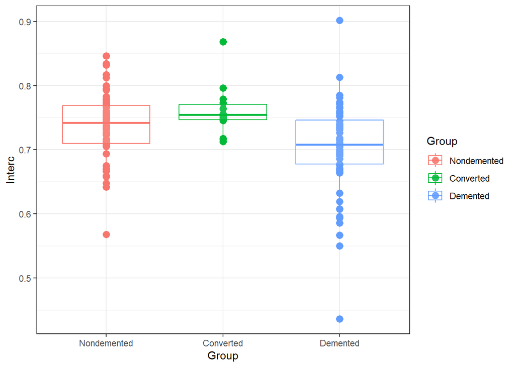

```r
###############plots

p <- ggplot(dati1lev,aes(Group,Interc,color=Group))
p+geom_point(size = 3) +geom_boxplot(alpha=.1) + theme_bw()
```

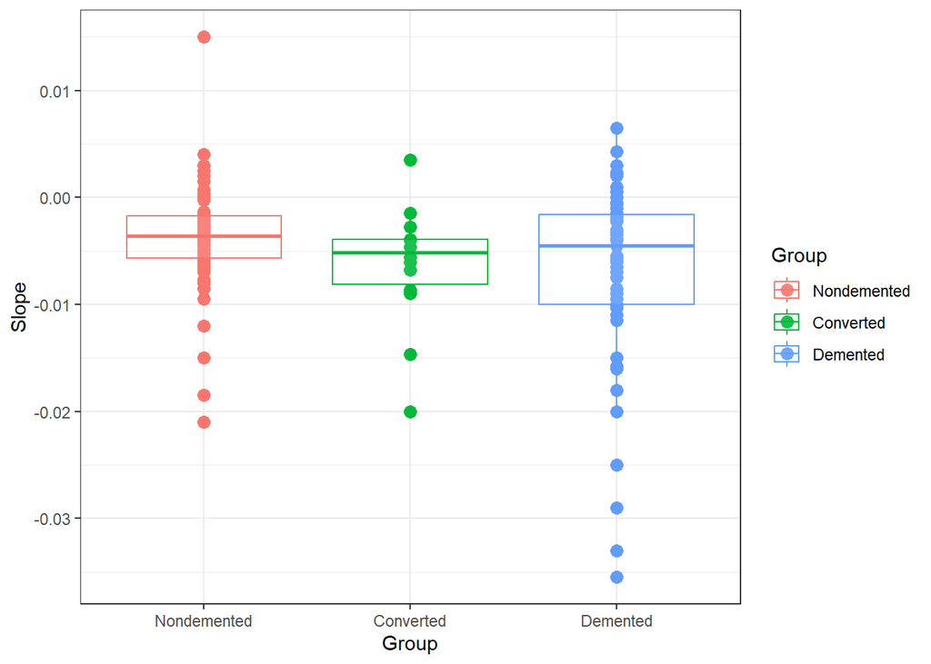

```r
p <- ggplot(dati1lev,aes(Group,Slope,color=Group))
p+geom_point(size = 3) +geom_boxplot(alpha=.1) + theme_bw()
```

```r
library(flipscores)

#Testing Intercept and Group (and any main effect between subjects):
res=flipscores(Interc~1+Group,data=dati1lev)
summary(res)
```

```
##
## Call:
## flipscores(formula = Interc ~ 1 + Group, data = dati1lev)
##
## Coefficients:
##                Estimate    Score Std. Error  z value Part. Cor Pr(>|z|)
## (Intercept)     0.73733 53.08751    4.39128 12.08929     0.994   0.0002 ***
## GroupConverted  0.02229  0.26123    0.19920  1.31139     0.108   0.0734 .
## GroupDemented  -0.03476 -1.17769    0.35035 -3.36141    -0.276   0.0006 ***
## ---
## Signif. codes:  0 '***' 0.001 '**' 0.01 '*' 0.05 '.' 0.1 ' ' 1
##
## (Dispersion parameter for gaussian family taken to be 0.003368959)
##
##     Null deviance: 0.55513  on 149  degrees of freedom
## Residual deviance: 0.49524  on 147  degrees of freedom
## AIC: -423.32
##
## Number of Fisher Scoring iterations: 2
```

```r
anova(res)
```

```
## Analysis of Deviance Table (Type III test)
##
## Model: gaussian, link: identity
##
## Inference is provided by FlipScores approach (5000 sign flips).
##
## Model: Interc ~ 1 + Group
##       Df Score Pr(>Score)
## Group  2 16.49      2e-04 ***
## ---
## Signif. codes:  0 '***' 0.001 '**' 0.01 '*' 0.05 '.' 0.1 ' ' 1
```

```r
#Testing Age and interaction Age:Group (and any interaction of between and within subject effects)
(res=flipscores(Slope~1+Group,data=dati1lev))
```

```
## Flip Score Test:
##          score_type = standardized , n_flips =
## Call: flipscores(formula = Slope ~ 1 + Group, data = dati1lev)
##
## Coefficients:
##    (Intercept) GroupConverted  GroupDemented
##   -0.003743808   -0.002542875   -0.003076956
```

```r
summary(res)
```

```
##
## Call:
## flipscores(formula = Slope ~ 1 + Group, data = dati1lev)
##
## Coefficients:
##                 Estimate     Score Std. Error   z value Part. Cor Pr(>|z|)
## (Intercept)    -0.003744 -0.269554   0.059885 -4.501172    -0.370   0.0002 ***
## GroupConverted -0.002543 -0.029805   0.022581 -1.319924    -0.108   0.1336
## GroupDemented  -0.003077 -0.104255   0.039116 -2.665270    -0.219   0.0094 **
## ---
## Signif. codes:  0 '***' 0.001 '**' 0.01 '*' 0.05 '.' 0.1 ' ' 1
##
## (Dispersion parameter for gaussian family taken to be 4.328286e-05)
##
##     Null deviance: 0.0066986  on 149  degrees of freedom
## Residual deviance: 0.0063626  on 147  degrees of freedom
## AIC: -1076.5
##
## Number of Fisher Scoring iterations: 2
```

```r
anova(res)
```

```
## Analysis of Deviance Table (Type III test)
##
## Model: gaussian, link: identity
##
## Inference is provided by FlipScores approach (5000 sign flips).
##
## Model: Slope ~ 1 + Group
##       Df  Score Pr(>Score)
## Group  2 7.6762     0.0128 *
## ---
## Signif. codes:  0 '***' 0.001 '**' 0.01 '*' 0.05 '.' 0.1 ' ' 1
```

# Profiles Clustering

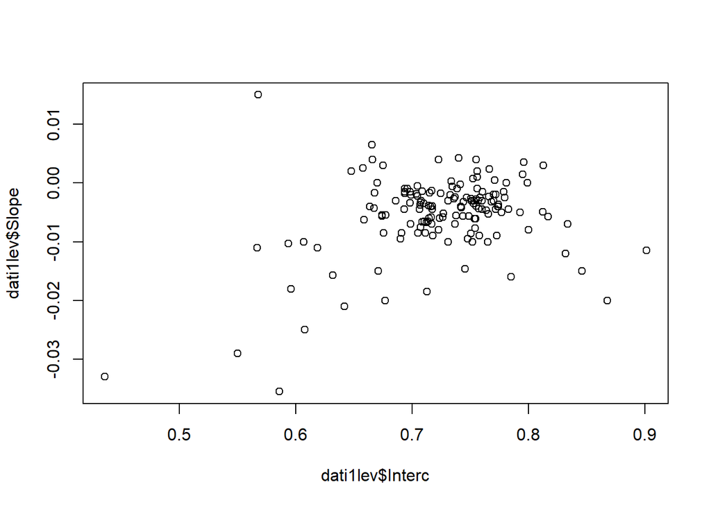

```r
plot(dati1lev$Interc,dati1lev$Slope)
```

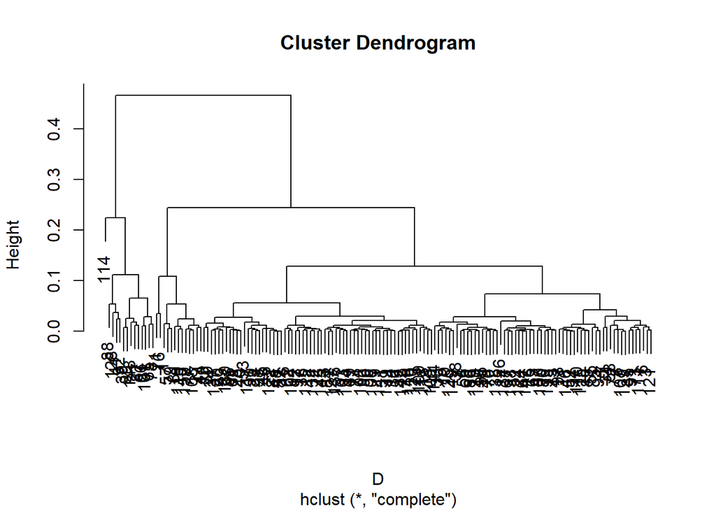

```r
D=dist(dati1lev[,c("Interc","Slope")])
hc=hclust(D,method = "complete")
plot(hc)
```

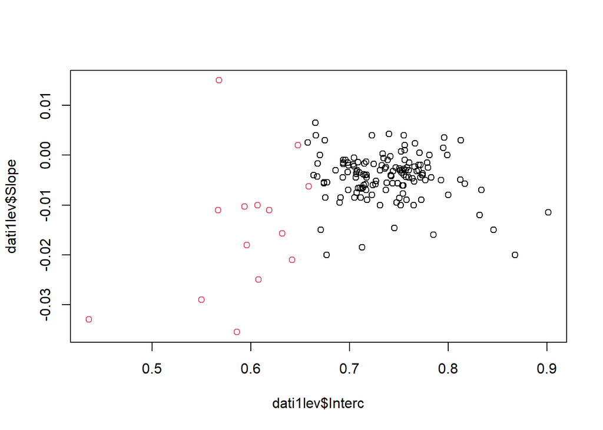

```r
clst=cutree(hc,2)
dati1lev$Cluster=clst
plot(dati1lev$Interc,dati1lev$Slope,col=dati1lev$Cluster)
```

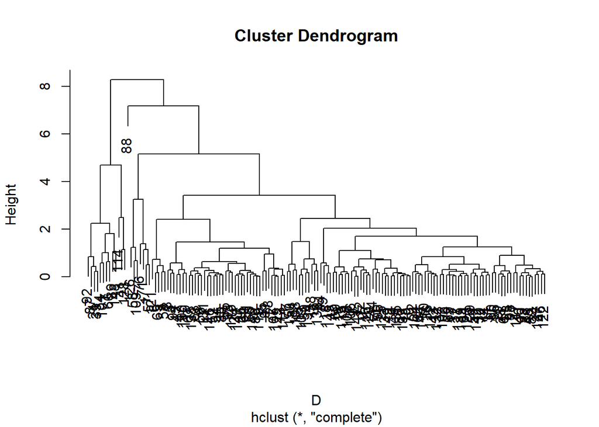

```r
dati1lev$Interc=scale(dati1lev$Interc)
dati1lev$Slope=scale(dati1lev$Slope)
D=dist(dati1lev[,c("Interc","Slope")])
hc=hclust(D,method = "complete")
plot(hc)
```

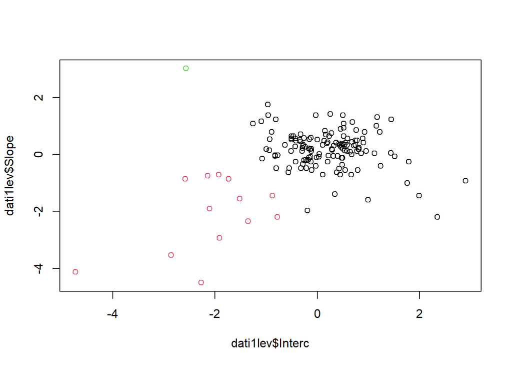

```r
clst=cutree(hc,3)
dati1lev$Cluster=clst
plot(dati1lev$Interc,dati1lev$Slope,col=dati1lev$Cluster)
```

```r
tab=table(dati1lev$Cluster,dati1lev$Group)
tab=tab[-3,]
chisq.test(tab)
```

```
##
##  Pearson's Chi-squared test
##
## data:  tab
## X-squared = 14.188, df = 2, p-value = 0.0008302
```

```r
library(tidyr)

temp=dati %>%
  group_by(Subject.ID) %>%
  summarize(Age=Age[1])
dati1lev=left_join(dati1lev,temp)
temp=dati %>%
  group_by(Subject.ID) %>%
  summarize(EDUC=EDUC[1])
dati1lev=left_join(dati1lev,temp)
```

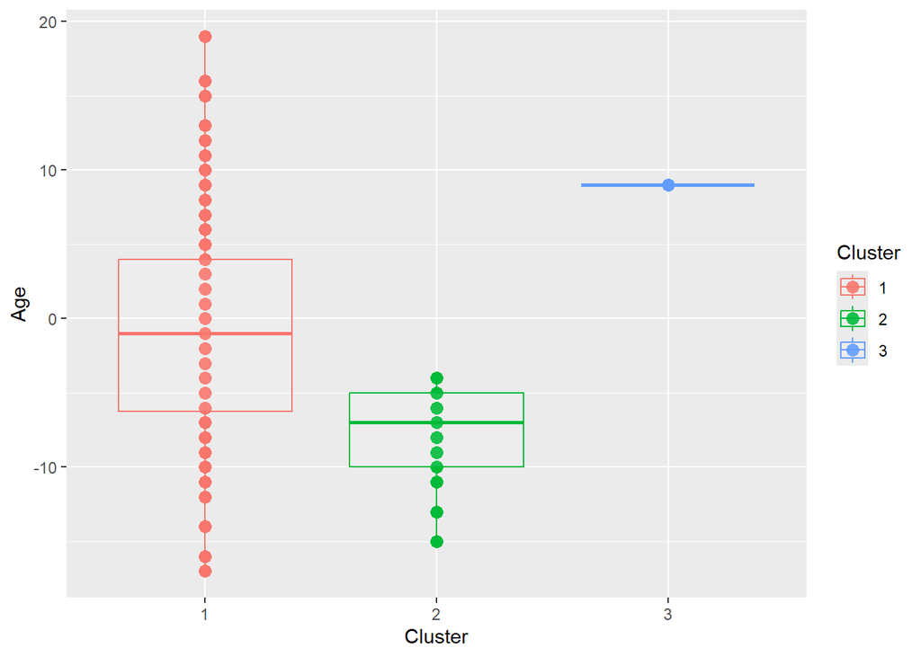

```r
dati1lev$Cluster=factor(dati1lev$Cluster)
p <- ggplot(dati1lev,aes(Cluster,Age,color=Cluster))
p+geom_point(size = 3) +geom_boxplot(alpha=.1)
```

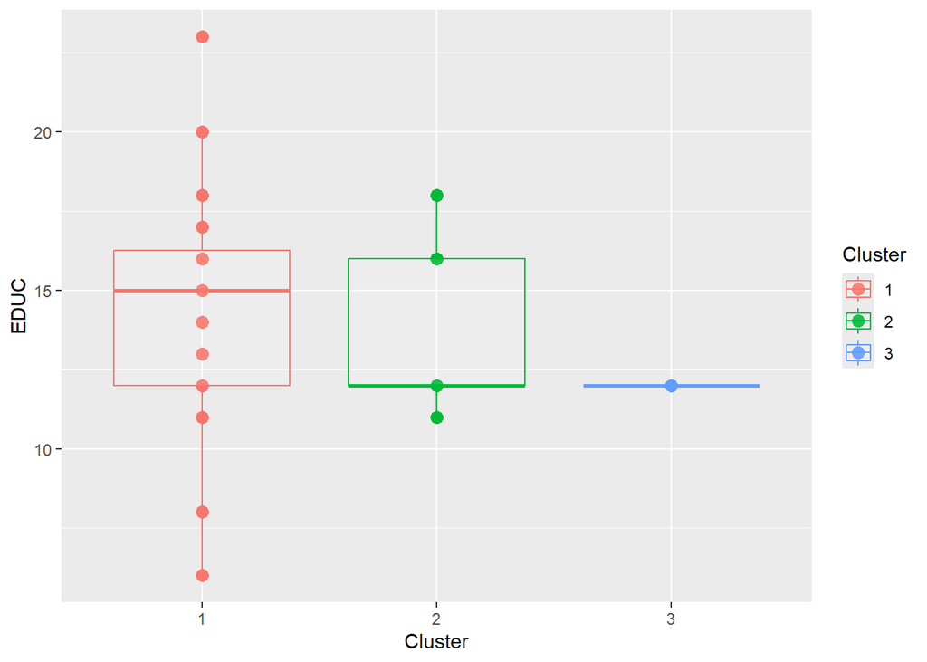

```r
p <- ggplot(dati1lev,aes(Cluster,EDUC,color=Cluster))
p+geom_point(size = 3) +geom_boxplot(alpha=.1)
```

```r
dati1lev$EDUC[dati1lev$Cluster==2]
```

```
##  [1] 12 18 12 16 12 12 16 11 12 11 16 12 16
```